# 02_deep_dives

#Eisenhower Expressway

## Black Residency

### 10-Yearly Census Tract

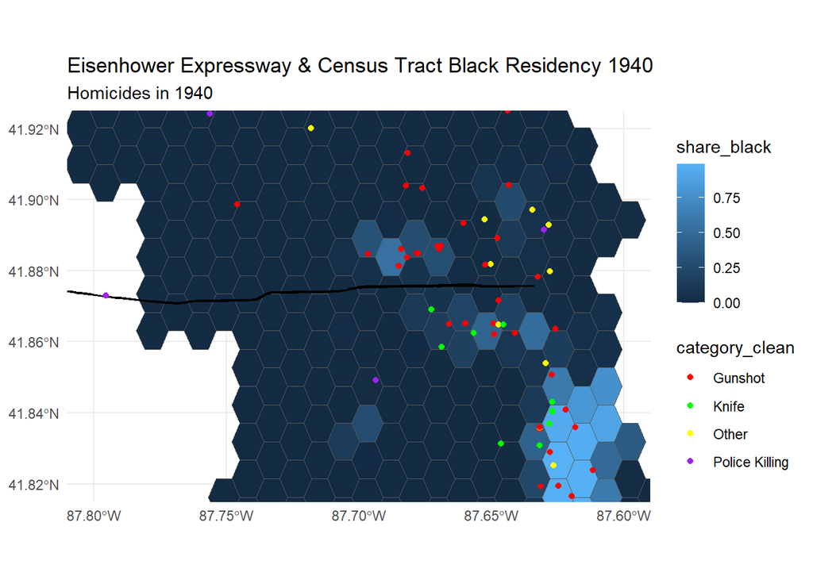

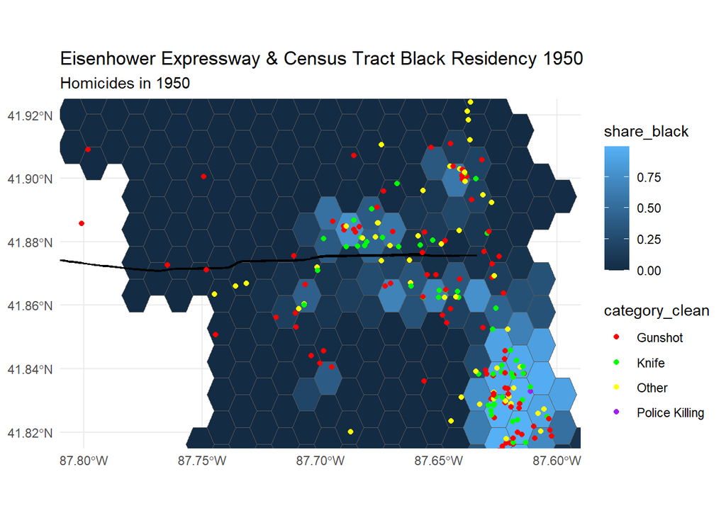

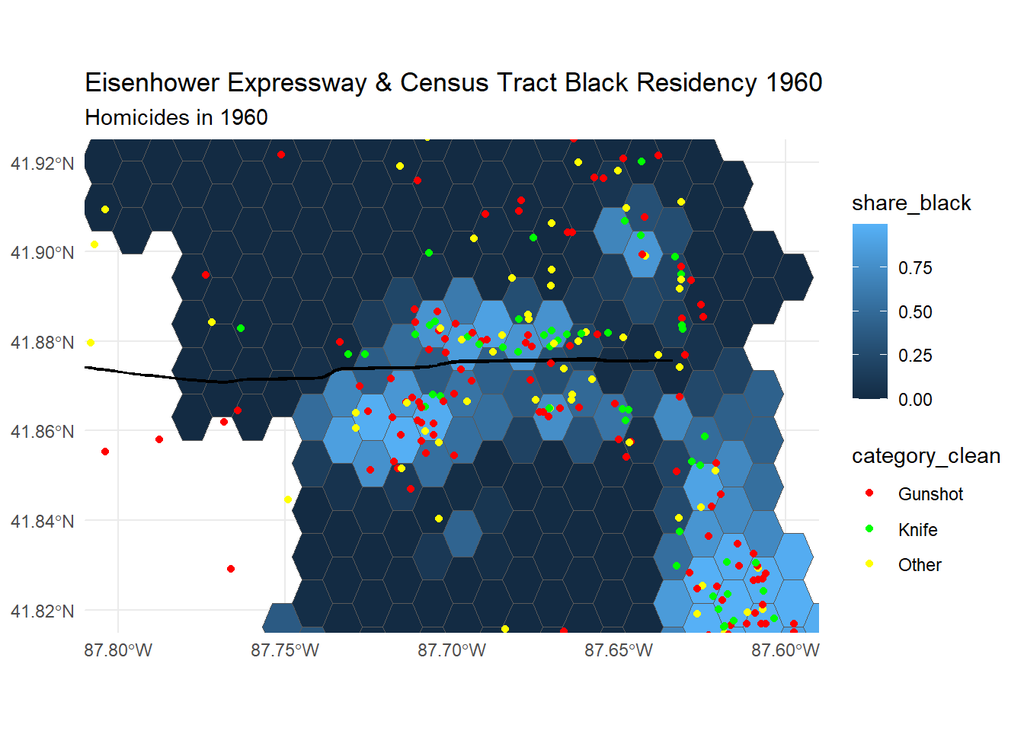

### 10-Yearly Census Tract

## Homicides and Black Residency

```r
knitr::include_graphics("output/eisenhower/homicides_share_black.gif")
```

[figure not shown]

```r
knitr::include_graphics("output/eisenhower/homicides_share_black_all.gif")
```

[figure not shown]

## Homicides and Population

```r
knitr::include_graphics("output/eisenhower/homicides_pop_concentration.gif")
```

[figure not shown]

## Homicides and Census Tracts

```r
knitr::include_graphics("output/eisenhower/homicides_census_grid.gif")
```

[figure not shown]

# Regression Data

```r
highway <- streets %>% filter(str_detect(DEDICATED_, "EISENHOWER EXPY"))

#Create distances from highway
buffer_distance <- 0.1*5280
highway_buffer_tenthtmile <- st_buffer(highway, dist = buffer_distance)
buffer_distance <- 0.25*5280
highway_buffer_quartmile <- st_buffer(highway, dist = buffer_distance)
buffer_distance <- 0.5*5280
highway_buffer_halfmile <- st_buffer(highway, dist = buffer_distance)
buffer_distance <- 1*5280
highway_buffer_1mile <- st_buffer(highway, dist = buffer_distance)


#Intersect with polygons
polygons_tenthmile_highway <- yearly_panel %>%
  filter(year == 1950) %>%
  dplyr::select(GRID_ID) %>%
  st_join(highway_buffer_tenthtmile, join = st_intersects, left = FALSE) %>%
  st_drop_geometry() %>%
  distinct(GRID_ID)

polygons_quartmile_highway <- yearly_panel %>%
  filter(year == 1950) %>%
  dplyr::select(GRID_ID) %>%
  st_join(highway_buffer_quartmile, join = st_intersects, left = FALSE) %>%
  st_drop_geometry() %>%
  distinct(GRID_ID)

polygons_halfmile_highway <- yearly_panel %>%
  filter(year == 1950) %>%
  dplyr::select(GRID_ID) %>%
  st_join(highway_buffer_halfmile, join = st_intersects, left = FALSE) %>%
  st_drop_geometry() %>%
  distinct(GRID_ID)

polygons_1_highway <- yearly_panel %>%
  filter(year == 1950) %>%
  dplyr::select(GRID_ID) %>%
  st_join(highway_buffer_1mile, join = st_intersects, left = FALSE) %>%
  st_drop_geometry() %>%
  distinct(GRID_ID)


#Create flags in data
reg_data <- yearly_panel %>%
  filter(year >= 1940 & year <= 1960) %>%
  mutate(flag_tenthmile_hway =
           ifelse(GRID_ID %in% c(polygons_tenthmile_highway$GRID_ID), 1, 0),
         flag_quartmile_hway =
           ifelse(GRID_ID %in% c(polygons_quartmile_highway$GRID_ID), 1, 0),
         flag_halfmile_hway =
           ifelse(GRID_ID %in% c(polygons_halfmile_highway$GRID_ID), 1, 0),
         flag_1mile_hway =
           ifelse(GRID_ID %in% c(polygons_1_highway$GRID_ID), 1, 0)) %>%
  mutate(flag_cat = case_when(flag_tenthmile_hway == 1 ~ "0.1 mile",
                              flag_quartmile_hway == 1 ~ "0.25 mile",
                              flag_halfmile_hway == 1 ~ "0.5 mile",
                              flag_1mile_hway == 1 ~ "1 mile",
                              TRUE ~ "> 1 mile")) %>%
  mutate(flag_constr = ifelse(year > 1949, 1, 0)) %>%
  mutate(flag_black_50 = ifelse(share_black > 0.5, 1, 0),
         flag_black_90 = ifelse(share_black > 0.9, 1, 0))
```

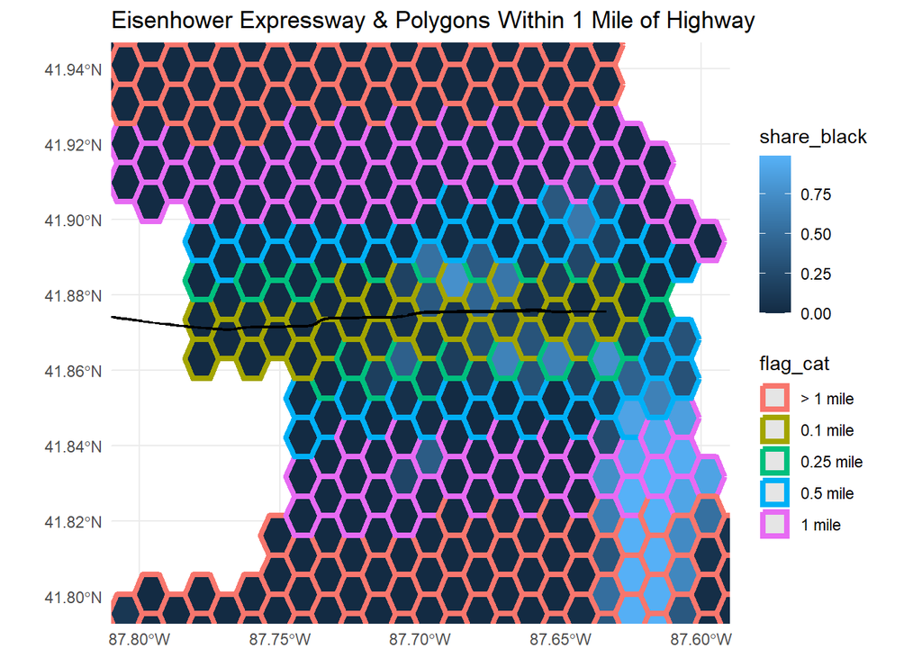

### Homicides and Black Residency with Segments

```r
knitr::include_graphics("output/eisenhower/homicides_share_black_mile_cats.gif")
```

[figure not shown]

### Census Tracts and Segments

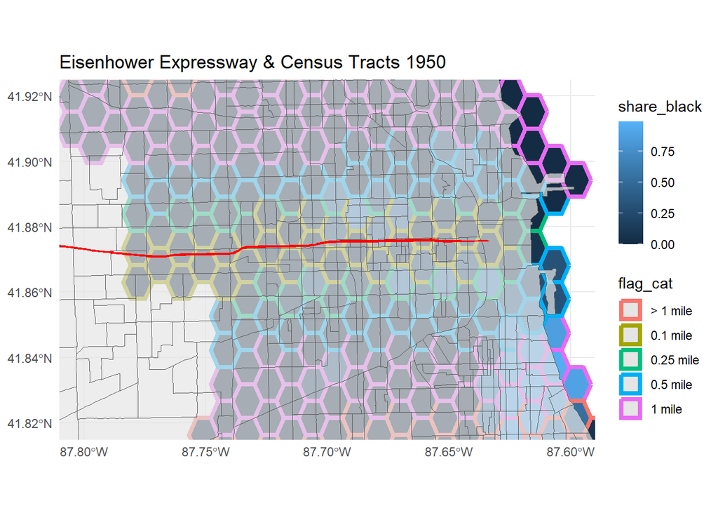

# Regressions

## Proximity only

### Halfmile against full mile no controls at all

Without controls, the highway clearly correlates with more homicides.

```r
reg_fe <- feglm(homicides ~ flag_constr:flag_halfmile_hway
              | year + GRID_ID
              , data = reg_data
              , family = "poisson")
```

```
## NOTE: 0/357 fixed-effects (7,497 observations) removed because of only 0 outcomes.
```

```r
summary(reg_fe)
```

```
## GLM estimation, family = poisson, Dep. Var.: homicides
## Observations: 9,744
## Fixed-effects: year: 21,  GRID_ID: 464
## Standard-errors: Clustered (year)
##                                Estimate Std. Error z value  Pr(>|z|)
## flag_constr:flag_halfmile_hway 0.254114   0.094496 2.68914 0.0071635 **
## ---
## Signif. codes:  0 '***' 0.001 '**' 0.01 '*' 0.05 '.' 0.1 ' ' 1
## Log-Likelihood: -6,397.5   Adj. Pseudo R2: 0.461094
##            BIC: 17,249.4     Squared Cor.: 0.663541
```

```r
reg_fe <- feglm(homicides ~ flag_constr:flag_quartmile_hway
              | year + GRID_ID
              , data = reg_data
              , family = "poisson")
```

```
## NOTE: 0/357 fixed-effects (7,497 observations) removed because of only 0 outcomes.
```

```r
summary(reg_fe)
```

```
## GLM estimation, family = poisson, Dep. Var.: homicides
## Observations: 9,744
## Fixed-effects: year: 21,  GRID_ID: 464
## Standard-errors: Clustered (year)
##                                 Estimate Std. Error z value   Pr(>|z|)
## flag_constr:flag_quartmile_hway 0.391102   0.107508  3.6379 0.00027487 ***
## ---
## Signif. codes:  0 '***' 0.001 '**' 0.01 '*' 0.05 '.' 0.1 ' ' 1
## Log-Likelihood: -6,388.4   Adj. Pseudo R2: 0.461803
##            BIC: 17,231.3     Squared Cor.: 0.664936
```

```r
reg_fe <- feglm(homicides ~ flag_constr:flag_tenthmile_hway
              | year + GRID_ID
              , data = reg_data
              , family = "poisson")
```

```
## NOTE: 0/357 fixed-effects (7,497 observations) removed because of only 0 outcomes.
```

```r
summary(reg_fe)
```

```
## GLM estimation, family = poisson, Dep. Var.: homicides
## Observations: 9,744
## Fixed-effects: year: 21,  GRID_ID: 464
## Standard-errors: Clustered (year)
##                                 Estimate Std. Error z value  Pr(>|z|)
## flag_constr:flag_tenthmile_hway 0.386784   0.099814 3.87505 0.0001066 ***
## ---
## Signif. codes:  0 '***' 0.001 '**' 0.01 '*' 0.05 '.' 0.1 ' ' 1
## Log-Likelihood: -6,394.4   Adj. Pseudo R2: 0.461336
##            BIC: 17,243.2     Squared Cor.: 0.663255
```

### Halfmile against full mile controlling only for black res

Controlling only for the share of black residency, we still see some effect of highway proximity. Effect is most pronounced the closer we get to highway.

```r
reg_fe <- feglm(homicides ~ flag_constr:flag_halfmile_hway
                + share_black
              | year + GRID_ID
              , data = reg_data
              , family = "poisson")
```

```
## NOTES: 720 observations removed because of NA values (RHS: 720).
##        0/359 fixed-effects (6,829 observations) removed because of only 0 outcomes.
```

```r
summary(reg_fe)
```

```
## GLM estimation, family = poisson, Dep. Var.: homicides
## Observations: 9,692
## Fixed-effects: year: 21,  GRID_ID: 462
## Standard-errors: Clustered (year)
##                                Estimate Std. Error   z value  Pr(>|z|)
## share_black                    2.436695   0.227520 10.709798 < 2.2e-16 ***
## flag_constr:flag_halfmile_hway 0.060769   0.077248  0.786675   0.43147
## ---
## Signif. codes:  0 '***' 0.001 '**' 0.01 '*' 0.05 '.' 0.1 ' ' 1
## Log-Likelihood: -6,219.8   Adj. Pseudo R2: 0.473826
##            BIC: 16,882.2     Squared Cor.: 0.713769
```

```r
reg_fe <- feglm(homicides ~ flag_constr:flag_quartmile_hway
                 + share_black
              | year + GRID_ID
              , data = reg_data
              , family = "poisson")
```

```
## NOTES: 720 observations removed because of NA values (RHS: 720).
##        0/359 fixed-effects (6,829 observations) removed because of only 0 outcomes.
```

```r
summary(reg_fe)
```

```
## GLM estimation, family = poisson, Dep. Var.: homicides
## Observations: 9,692
## Fixed-effects: year: 21,  GRID_ID: 462
## Standard-errors: Clustered (year)
##                                 Estimate Std. Error  z value  Pr(>|z|)
## share_black                     2.399467   0.224760 10.67567 < 2.2e-16 ***
## flag_constr:flag_quartmile_hway 0.151620   0.088073  1.72153  0.085154 .
## ---
## Signif. codes:  0 '***' 0.001 '**' 0.01 '*' 0.05 '.' 0.1 ' ' 1
## Log-Likelihood: -6,217.7   Adj. Pseudo R2: 0.47399
##            BIC: 16,878.1     Squared Cor.: 0.713981
```

```r
reg_fe <- feglm(homicides ~ flag_constr:flag_tenthmile_hway
                 + share_black
              | year + GRID_ID
              , data = reg_data
              , family = "poisson")
```

```
## NOTES: 720 observations removed because of NA values (RHS: 720).
##        0/359 fixed-effects (6,829 observations) removed because of only 0 outcomes.
```

```r
summary(reg_fe)
```

```
## GLM estimation, family = poisson, Dep. Var.: homicides
## Observations: 9,692
## Fixed-effects: year: 21,  GRID_ID: 462
## Standard-errors: Clustered (year)
##                                 Estimate Std. Error  z value  Pr(>|z|)
## share_black                     2.414964   0.229816 10.50824 < 2.2e-16 ***
## flag_constr:flag_tenthmile_hway 0.211647   0.089411  2.36712  0.017927 *
## ---
## Signif. codes:  0 '***' 0.001 '**' 0.01 '*' 0.05 '.' 0.1 ' ' 1
## Log-Likelihood: -6,216.6   Adj. Pseudo R2: 0.474075
##            BIC: 16,875.9     Squared Cor.: 0.714594
```

### Tenthmile against full mile with employment, college grad ratio, and population and fixed effects

```r
reg_fe <- feglm(homicides ~  flag_constr*flag_tenthmile_hway
                 + share_white +  share_black + share_foreign +
                  share_unemployed + share_college_grad
                 + log(total_pop)
              | year + GRID_ID
              , data = reg_data %>% filter(flag_1mile_hway == 1)
              , family = "poisson")
```

```
## NOTES: 70 observations removed because of NA values (RHS: 70).
##        0/41 fixed-effects (791 observations) removed because of only 0 outcomes.
```

```
## The variables 'flag_constr' and 'flag_tenthmile_hway' have been removed because of collinearity (see $collin.var).
```

```r
summary(reg_fe)
```

```
## GLM estimation, family = poisson, Dep. Var.: homicides
## Observations: 3,318
## Fixed-effects: year: 21,  GRID_ID: 158
## Standard-errors: Clustered (year)
##                                  Estimate Std. Error   z value Pr(>|z|)
## share_white                      5.474730   4.520873  1.210989 0.225899
## share_black                      7.481299   4.685577  1.596666 0.110340
## share_foreign                    0.383510   0.409355  0.936862 0.348829
## share_unemployed                 2.317670   1.057502  2.191646 0.028405 *
## share_college_grad              -6.018439   2.355624 -2.554923 0.010621 *
## log(total_pop)                   0.464655   0.403899  1.150426 0.249968
## flag_constr:flag_tenthmile_hway  0.212565   0.086782  2.449406 0.014309 *
## ... 2 variables were removed because of collinearity (flag_constr and flag_tenthmile_hway)
## ---
## Signif. codes:  0 '***' 0.001 '**' 0.01 '*' 0.05 '.' 0.1 ' ' 1
## Log-Likelihood: -3,000.7   Adj. Pseudo R2: 0.444536
##            BIC:  7,501.3     Squared Cor.: 0.696403
```

### Tenthmile against full mile with employment and college grad ratio + Unhoused and fixed effects

```r
reg_fe <- feglm(homicides ~  flag_constr*flag_tenthmile_hway
                 + share_white +  share_black + share_foreign +
                  share_unemployed +share_college_grad
                + has_housing*share_unemployed + has_housing*share_black
                 + log(total_pop)
              | year + GRID_ID
              , data = reg_data %>% filter(flag_1mile_hway == 1)
              , family = "poisson")
```

```
## NOTES: 70 observations removed because of NA values (RHS: 70).
##        0/41 fixed-effects (791 observations) removed because of only 0 outcomes.
```

```
## The variables 'flag_constr' and 'flag_tenthmile_hway' have been removed because of collinearity (see $collin.var).
```

```r
summary(reg_fe)
```

```
## GLM estimation, family = poisson, Dep. Var.: homicides
## Observations: 3,318
## Fixed-effects: year: 21,  GRID_ID: 158
## Standard-errors: Clustered (year)
##                                  Estimate Std. Error   z value  Pr(>|z|)
## share_white                      6.367067   4.392165  1.449642 0.1471584
## share_black                      8.275270   4.540375  1.822596 0.0683645 .
## share_foreign                    0.503117   0.407882  1.233487 0.2173942
## share_unemployed                 2.151104   1.033026  2.082333 0.0373121 *
## share_college_grad              -4.962774   2.470651 -2.008691 0.0445699 *
## has_housing                      0.646699   0.416168  1.553938 0.1201993
## log(total_pop)                   0.724840   0.463875  1.562576 0.1181524
## flag_constr:flag_tenthmile_hway  0.168955   0.089333  1.891290 0.0585856 .
## share_unemployed:has_housing     0.019870   1.337341  0.014858 0.9881456
## share_black:has_housing         -1.106385   0.414383 -2.669956 0.0075861 **
## ... 2 variables were removed because of collinearity (flag_constr and flag_tenthmile_hway)
## ---
## Signif. codes:  0 '***' 0.001 '**' 0.01 '*' 0.05 '.' 0.1 ' ' 1
## Log-Likelihood: -2,994.0   Adj. Pseudo R2: 0.445188
##            BIC:  7,512.1     Squared Cor.: 0.701701
```

### Tenthmile against full mile with employment and college grad ratio + Unhoused + Vacant Homes and fixed effects

Adding vacant homes as an interactive controls destroys the effect

```r
reg_fe <- feglm(homicides ~  flag_constr*flag_tenthmile_hway
                 + share_white +  share_foreign +
                  share_unemployed +share_college_grad
                + has_housing * share_black + has_housing*share_unemployed
                + share_vacant_homes*share_black
                 + log(total_pop)
              | year + GRID_ID
              , data = reg_data %>% filter(flag_1mile_hway == 1)
              , family = "poisson")
```

```
## NOTES: 70 observations removed because of NA values (RHS: 70).
##        0/41 fixed-effects (791 observations) removed because of only 0 outcomes.
```

```
## The variables 'flag_constr' and 'flag_tenthmile_hway' have been removed because of collinearity (see $collin.var).
```

```r
summary(reg_fe)
```

```
## GLM estimation, family = poisson, Dep. Var.: homicides
## Observations: 3,318
## Fixed-effects: year: 21,  GRID_ID: 158
## Standard-errors: Clustered (year)
##                                  Estimate Std. Error   z value   Pr(>|z|)
## share_white                     10.856140   4.527918  2.397601 0.01650282 *
## share_foreign                    0.264135   0.403017  0.655394 0.51221440
## share_unemployed                 2.044876   1.056502  1.935515 0.05292716 .
## share_college_grad              -3.498429   2.519147 -1.388735 0.16491320
## has_housing                      0.226346   0.425485  0.531973 0.59474495
## share_black                     13.502873   4.650176  2.903734 0.00368742 **
## share_vacant_homes               2.171505   0.791775  2.742579 0.00609588 **
## log(total_pop)                   0.693056   0.452020  1.533241 0.12521648
## flag_constr:flag_tenthmile_hway  0.122852   0.090179  1.362318 0.17309771
## has_housing:share_black         -0.659950   0.416850 -1.583183 0.11337972
## share_unemployed:has_housing     1.385630   1.373902  1.008536 0.31319712
## share_black:share_vacant_homes  -5.424965   1.474518 -3.679145 0.00023402 ***
## ... 2 variables were removed because of collinearity (flag_constr and flag_tenthmile_hway)
## ---
## Signif. codes:  0 '***' 0.001 '**' 0.01 '*' 0.05 '.' 0.1 ' ' 1
## Log-Likelihood: -2,982.8   Adj. Pseudo R2: 0.446798
##            BIC:  7,505.9     Squared Cor.: 0.706604
```

## Proximity + Black Residency

There is some evidence that homicicides increase more for areas with higher black residency near highway

### No controls

```r
reg_fe <- feglm(homicides ~ flag_constr * flag_tenthmile_hway * flag_black_50
              | year + GRID_ID
              , data = reg_data %>% filter(flag_1mile_hway == 1)
              , family = "poisson")
```

```
## NOTES: 70 observations removed because of NA values (RHS: 70).
##        0/41 fixed-effects (791 observations) removed because of only 0 outcomes.
```

```
## The variables 'flag_constr' and 'flag_tenthmile_hway' have been removed because of collinearity (see $collin.var).
```

```r
summary(reg_fe)
```

```
## GLM estimation, family = poisson, Dep. Var.: homicides
## Observations: 3,318
## Fixed-effects: year: 21,  GRID_ID: 158
## Standard-errors: Clustered (year)
##                                                Estimate Std. Error   z value
## flag_black_50                                  0.972438   0.237109  4.101229
## flag_constr:flag_tenthmile_hway                0.098387   0.119693  0.821995
## flag_constr:flag_black_50                     -0.241074   0.167269 -1.441235
## flag_tenthmile_hway:flag_black_50             -0.523780   0.373154 -1.403656
## flag_constr:flag_tenthmile_hway:flag_black_50  0.911761   0.297156  3.068291
##                                                 Pr(>|z|)
## flag_black_50                                 4.1096e-05 ***
## flag_constr:flag_tenthmile_hway               4.1108e-01
## flag_constr:flag_black_50                     1.4952e-01
## flag_tenthmile_hway:flag_black_50             1.6042e-01
## flag_constr:flag_tenthmile_hway:flag_black_50 2.1529e-03 **
## ... 2 variables were removed because of collinearity (flag_constr and flag_tenthmile_hway)
## ---
## Signif. codes:  0 '***' 0.001 '**' 0.01 '*' 0.05 '.' 0.1 ' ' 1
## Log-Likelihood: -3,062.4   Adj. Pseudo R2: 0.434133
##            BIC:  7,608.4     Squared Cor.: 0.659738
```

### All controls

```r
reg_fe <- feglm(homicides ~ flag_constr * flag_tenthmile_hway * flag_black_50
                + share_white +  share_foreign +
                  share_unemployed +share_college_grad
                + has_housing * share_black + has_housing*share_unemployed
                + share_vacant_homes*share_black
                 + log(total_pop)
              | year + GRID_ID
              , data = reg_data %>% filter(flag_1mile_hway == 1)
              , family = "poisson")
```

```
## NOTES: 70 observations removed because of NA values (RHS: 70).
##        0/41 fixed-effects (791 observations) removed because of only 0 outcomes.
```

```
## The variables 'flag_constr' and 'flag_tenthmile_hway' have been removed because of collinearity (see $collin.var).
```

```r
summary(reg_fe)
```

```
## GLM estimation, family = poisson, Dep. Var.: homicides
## Observations: 3,318
## Fixed-effects: year: 21,  GRID_ID: 158
## Standard-errors: Clustered (year)
##                                                Estimate Std. Error   z value
## flag_black_50                                  0.052055   0.187281  0.277953
## share_white                                   10.815781   4.418951  2.447590
## share_foreign                                 -0.076860   0.354899 -0.216568
## share_unemployed                               1.890117   1.035343  1.825595
## share_college_grad                            -3.406864   2.436411 -1.398312
## has_housing                                    0.163760   0.415731  0.393910
## share_black                                   13.150471   4.434690  2.965364
## share_vacant_homes                             2.364896   0.756875  3.124552
## log(total_pop)                                 0.712407   0.457586  1.556880
## flag_constr:flag_tenthmile_hway                0.043081   0.108210  0.398124
## flag_constr:flag_black_50                      0.109068   0.124863  0.873496
## flag_tenthmile_hway:flag_black_50             -0.295324   0.351853 -0.839339
## has_housing:share_black                       -0.626209   0.414785 -1.509720
## share_unemployed:has_housing                   1.537464   1.322342  1.162683
## share_black:share_vacant_homes                -6.299922   1.286314 -4.897653
## flag_constr:flag_tenthmile_hway:flag_black_50  0.512408   0.287608  1.781619
##                                                 Pr(>|z|)
## flag_black_50                                 7.8105e-01
## share_white                                   1.4382e-02 *
## share_foreign                                 8.2854e-01
## share_unemployed                              6.7911e-02 .
## share_college_grad                            1.6202e-01
## has_housing                                   6.9365e-01
## share_black                                   3.0233e-03 **
## share_vacant_homes                            1.7808e-03 **
## log(total_pop)                                1.1950e-01
## flag_constr:flag_tenthmile_hway               6.9054e-01
## flag_constr:flag_black_50                     3.8239e-01
## flag_tenthmile_hway:flag_black_50             4.0128e-01
## has_housing:share_black                       1.3112e-01
## share_unemployed:has_housing                  2.4496e-01
## share_black:share_vacant_homes                9.6988e-07 ***
## flag_constr:flag_tenthmile_hway:flag_black_50 7.4811e-02 .
## ... 2 variables were removed because of collinearity (flag_constr and flag_tenthmile_hway)
## ---
## Signif. codes:  0 '***' 0.001 '**' 0.01 '*' 0.05 '.' 0.1 ' ' 1
## Log-Likelihood: -2,977.7   Adj. Pseudo R2: 0.446989
##            BIC:  7,528.1     Squared Cor.: 0.709659
```

### All controls & Comparison against all Chicago

Interesting: that effect is more pronounced when we compare it against all of Chicago

```r
reg_fe <- feglm(homicides ~ flag_constr * flag_tenthmile_hway * flag_black_50
                + share_white +  share_foreign +
                  share_unemployed +  share_college_grad
                + has_housing * share_black + has_housing*share_unemployed
                + share_vacant_homes*share_black
                 + log(total_pop)
              | year + GRID_ID
              , data = reg_data
              , family = "poisson")
```

```
## NOTES: 721 observations removed because of NA and infinite values (RHS: 721).
##        0/359 fixed-effects (6,828 observations) removed because of only 0 outcomes.
```

```
## The variables 'flag_constr' and 'flag_tenthmile_hway' have been removed because of collinearity (see $collin.var).
```

```r
summary(reg_fe)
```

```
## GLM estimation, family = poisson, Dep. Var.: homicides
## Observations: 9,692
## Fixed-effects: year: 21,  GRID_ID: 462
## Standard-errors: Clustered (year)
##                                                Estimate Std. Error   z value
## flag_black_50                                  0.092894   0.127587  0.728088
## share_white                                   -1.255706   2.706381 -0.463980
## share_foreign                                  0.005497   0.201460  0.027285
## share_unemployed                               0.303219   0.990216  0.306215
## share_college_grad                            -5.199536   2.099144 -2.476979
## has_housing                                    0.029332   0.377342  0.077734
## share_black                                    0.647016   2.838493  0.227944
## share_vacant_homes                             1.261462   0.814452  1.548848
## log(total_pop)                                 0.726334   0.189317  3.836600
## flag_constr:flag_tenthmile_hway                0.059700   0.119823  0.498239
## flag_constr:flag_black_50                     -0.009768   0.095522 -0.102260
## flag_tenthmile_hway:flag_black_50             -0.198285   0.319853 -0.619925
## has_housing:share_black                       -0.536068   0.356418 -1.504044
## share_unemployed:has_housing                   1.100793   1.395295  0.788932
## share_black:share_vacant_homes                -3.642639   0.883974 -4.120755
## flag_constr:flag_tenthmile_hway:flag_black_50  0.540106   0.262794  2.055246
##                                                 Pr(>|z|)
## flag_black_50                                 4.6656e-01
## share_white                                   6.4266e-01
## share_foreign                                 9.7823e-01
## share_unemployed                              7.5944e-01
## share_college_grad                            1.3250e-02 *
## has_housing                                   9.3804e-01
## share_black                                   8.1969e-01
## share_vacant_homes                            1.2142e-01
## log(total_pop)                                1.2475e-04 ***
## flag_constr:flag_tenthmile_hway               6.1832e-01
## flag_constr:flag_black_50                     9.1855e-01
## flag_tenthmile_hway:flag_black_50             5.3531e-01
## has_housing:share_black                       1.3257e-01
## share_unemployed:has_housing                  4.3015e-01
## share_black:share_vacant_homes                3.7763e-05 ***
## flag_constr:flag_tenthmile_hway:flag_black_50 3.9855e-02 *
## ... 2 variables were removed because of collinearity (flag_constr and flag_tenthmile_hway)
## ---
## Signif. codes:  0 '***' 0.001 '**' 0.01 '*' 0.05 '.' 0.1 ' ' 1
## Log-Likelihood: -6,163.9   Adj. Pseudo R2: 0.477116
##            BIC: 16,898.9     Squared Cor.: 0.724803
```

# Appendix

## Notes

To do:

Look into general increases and decreases in homicides

Expressway info:

- 1940 Superhighway System established Congress Street Expressway (or “Westside Route”), officially authorized for construction on October 31, 1940.
- Actual construction didn’t begin until December 7, 1949
- Look into Relocation Housing Projects by CHA
- Look into Hospital Construction

Opening:

- The first section opened between South Ashland Avenue and South Laramie Avenue on December 15, 1955
- The remainder of the route between South Ashland Avenue and Grant Park in Downtown Chicago opened on August 10, 1956
- Various segments between Mannheim Road (US12/20/45) and Racine Avenue were completed between 1954 and 1960

## 1950 UIC Black Residency Maps

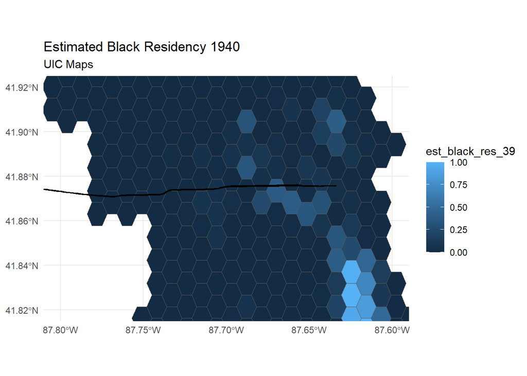

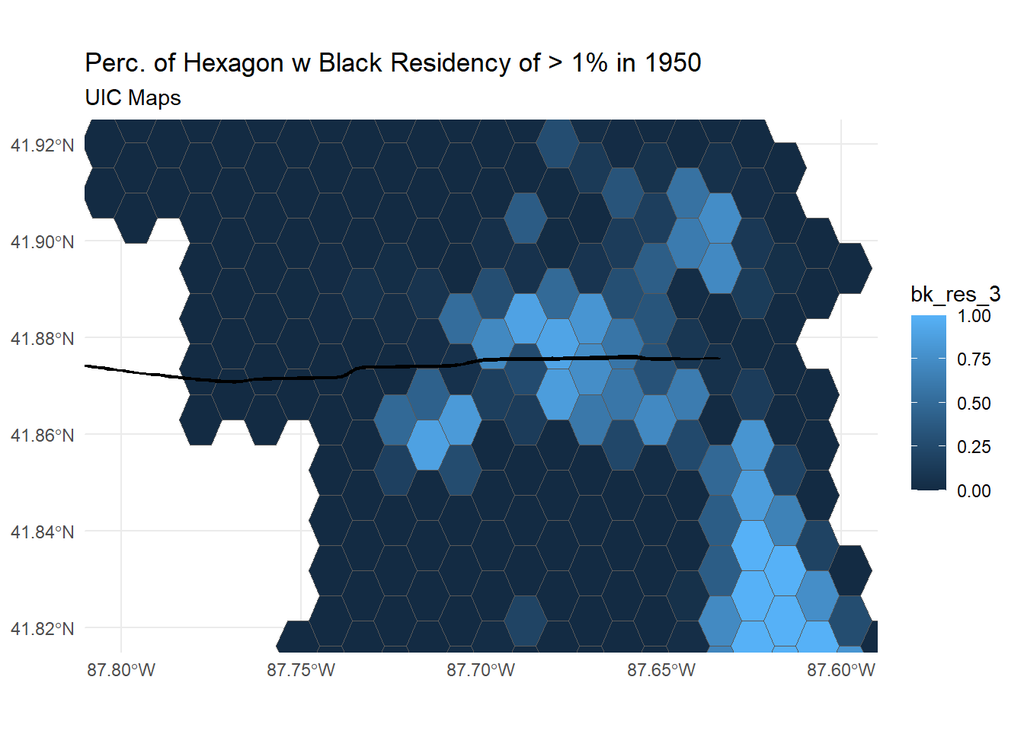

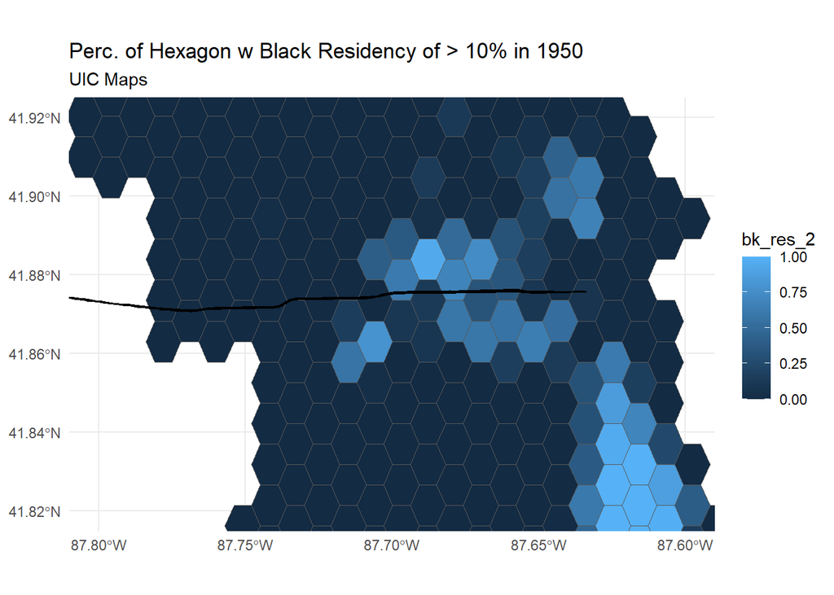

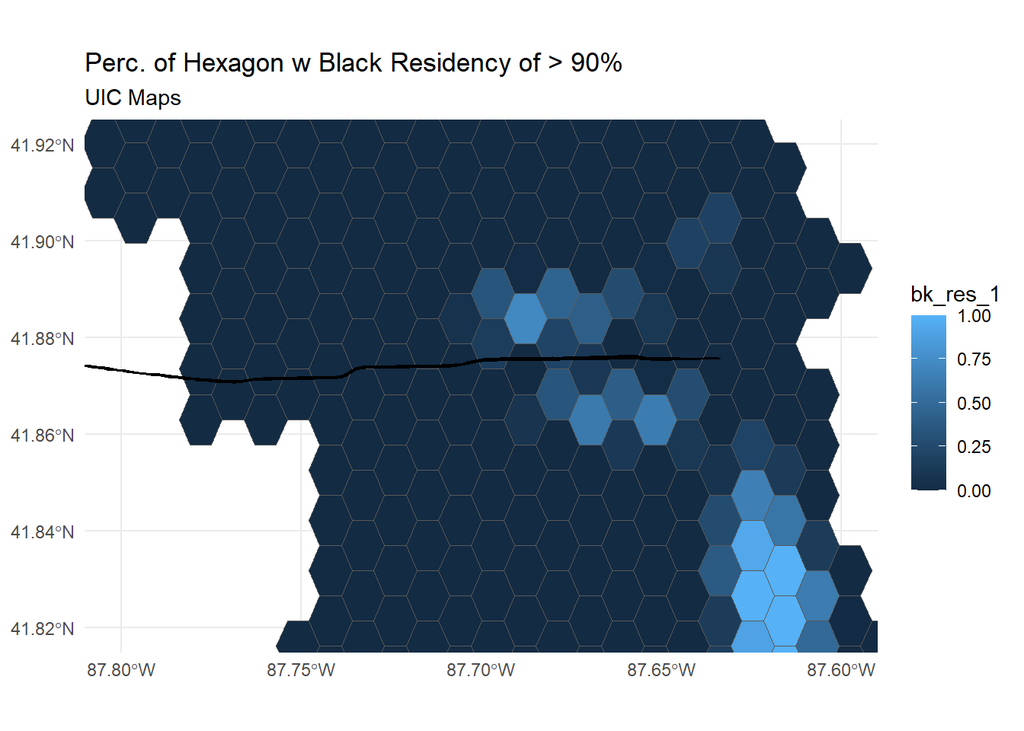

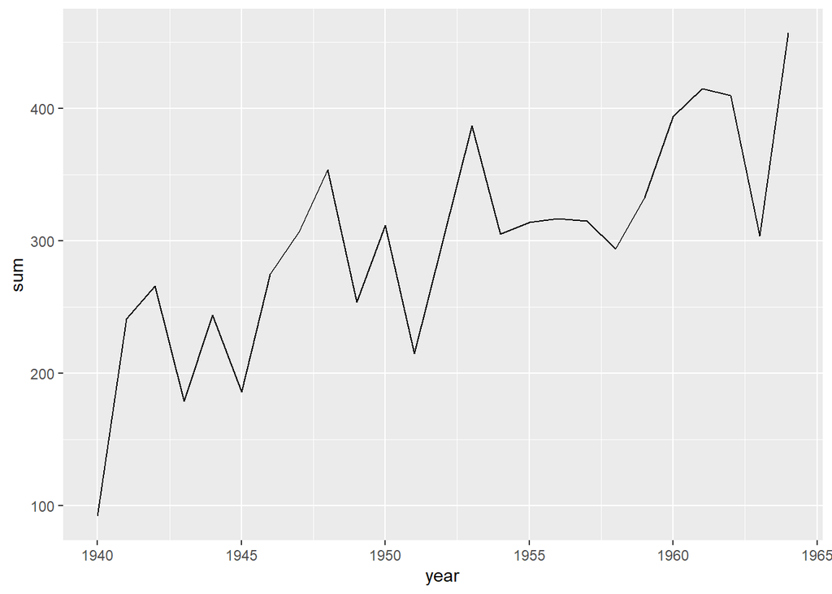

```r
plot_data <- homs %>%
  st_drop_geometry() %>%
  group_by(year) %>%
  summarise(sum = n()) %>%
  ungroup()


ggplot(data = plot_data ) +
  geom_line(aes(x = year, y = sum))
```